# Data Analytics Practicals 5 & 6 ~Airbnb many more useful tests & linear regression models

Eryk Gloginski

16/03/2023

```r
#install.packages("tidyverse")
#install.packages("gridExtra") #this package helps to organise figure output from ggplot
library(tidyverse)
library(gridExtra)
```

#make sure to save your “.RData” file (Airbnb.RData) in your current working directory.

```r
getwd()
```

```
## [1] "D:/Year 3/Semester 6/Data Analytics/Practicals/Practical5and6"
```

```r
#setwd("I:/Year 3/Semester 6/Data Analytics/Practicals/Practical5and6")
getwd()
```

```
## [1] "D:/Year 3/Semester 6/Data Analytics/Practicals/Practical5and6"
```

```r
list.files()
```

```
## [1] "airbnb.RData"                       "crime.csv"
## [3] "Pr5_6_erykgloginski_20230313.html"  "Pr5_6_erykgloginski_20230313.Rmd"
## [5] "Pr5_6_erykgloginski_20230313_files" "practical5_6.rar"
## [7] "practical5_6.zip"                   "PROTEIN.CSV"
```

```r
airbnb <- load("airbnb.RData")
airbnb
```

```
##  [1] "iceland"      "paris"        "copenhagen"   "warsaw"       "amsterdam"
##  [6] "edinburgh"    "barcelona"    ".Random.seed" "london"       "dublin"
```

```r
ls(paris)
```

```
##  [1] "accommodates"         "bathrooms"            "bedrooms"
##  [4] "borough"              "city"                 "country"
##  [7] "host_id"              "last_modified"        "latitude"
## [10] "location"             "longitude"            "minstay"
## [13] "name"                 "neighborhood"         "overall_satisfaction"
## [16] "price"                "property_type"        "reviews"
## [19] "room_id"              "room_type"            "survey_id"
```

```r
ls(copenhagen)
```

```
##  [1] "accommodates"         "bathrooms"            "bedrooms"
##  [4] "borough"              "city"                 "country"
##  [7] "host_id"              "last_modified"        "latitude"
## [10] "location"             "longitude"            "minstay"
## [13] "neighborhood"         "overall_satisfaction" "price"
## [16] "reviews"              "room_id"              "room_type"
## [19] "survey_id"
```

#run the code chunks below and complete all of the short exercises. The entire notebook should be submitted at the end of week 9.

# t-test assumptions

#First we re-run the t-test that we undertook last week in order to discuss some of the assumptions underlying it.

```r
paris$logprice=log(paris$price)
copenhagen$logprice=log(copenhagen$price)

ttest <- t.test(paris$logprice, copenhagen$logprice, var.equal = FALSE)
ttest
```

```
##
##  Welch Two Sample t-test
##
## data:  paris$logprice and copenhagen$logprice
## t = -35.895, df = 40812, p-value < 2.2e-16
## alternative hypothesis: true difference in means is not equal to 0
## 95 percent confidence interval:
##  -0.1520485 -0.1363034
## sample estimates:
## mean of x mean of y
##  4.502147  4.646323
```

#Below are listed some key assumptions ythat ahve to be true about the data before using a 2 sample t-test.

#1~The data in each variable are normally distributed (in the population).

#2~The distribution (spread) of the variable of interest is the same in both populations.

#3~All observations in each distribution are independent of each other (the value of one ob. does not influence that of another)

#NOTE: we assessed only the first of these assumptions for this t-test, i.e. the normal distribution of variables.

#It is important also to test the second assumption- the spread of tghe variable sis the same, to do this, we perform a comaprison of the variances using another test called the F-test (also used in ANOVA) before performing the t-test. Here our null hypothesis (Ho) is that there is no differnece in the variances of the two data distributions- the test statitic is a ratio of the two variances, if they are the same the ratio should be equal to one accouting for degress of freedom (essentially the sample sizes that we have).

```r
#check for equality of variances (F test to determine if their ratio is equal to 1) of the two price variables)

res.ftest <- var.test(paris$logprice, copenhagen$logprice)
res.ftest
```

```
##
##  F test to compare two variances
##
## data:  paris$logprice and copenhagen$logprice
## F = 1.3865, num df = 70157, denom df = 21300, p-value < 2.2e-16
## alternative hypothesis: true ratio of variances is not equal to 1
## 95 percent confidence interval:
##  1.356674 1.416807
## sample estimates:
## ratio of variances
##           1.386503
```

#Therefore the variances are not the same in the two popualtions based on our samples.

#The specific type of 2-sample T-test in which the variances of the two samples are not equal is known as a Welch Two Sample t-test.

#You can raed out it here and constrast it with the standrd 2-sample t-test when variances are equal.

```r
ttest_falsev <- t.test(paris$logprice, copenhagen$logprice, var.equal = FALSE)
ttest_falsev
```

```
##
##  Welch Two Sample t-test
##
## data:  paris$logprice and copenhagen$logprice
## t = -35.895, df = 40812, p-value < 2.2e-16
## alternative hypothesis: true difference in means is not equal to 0
## 95 percent confidence interval:
##  -0.1520485 -0.1363034
## sample estimates:
## mean of x mean of y
##  4.502147  4.646323
```

```r
ttest_truev <- t.test(paris$logprice, copenhagen$logprice, var.equal = TRUE)
ttest_truev
```

```
##
##  Two Sample t-test
##
## data:  paris$logprice and copenhagen$logprice
## t = -32.913, df = 91457, p-value < 2.2e-16
## alternative hypothesis: true difference in means is not equal to 0
## 95 percent confidence interval:
##  -0.1527617 -0.1355903
## sample estimates:
## mean of x mean of y
##  4.502147  4.646323
```

#note the differences (t-value and df) in the results of the standard 2-sample t-test and the Welch t-test.

#Here the t-value (difference) is so large that it does not imapct the p-value, but with smaller sample sizes, unequal varinaces will impact the results and its important to always perform a F-tets to assess varinaces before performing a 2-sample t-test.

#Now one more important assumption remains.

#~That is 3. All observations in each distribution are independent of each other (the value of one ob. does not influence that of another).

#This is usually only an issue for repeated measures data (e.g. before and after data on the same individual) where the value of an observation in the first sample directly influences the value of an obervation in the second sample.

#In these cases we use a paired t-test if we have 2 sample or groups, we use a repeated measures ANOVA if we have more than 2 groups.

#………………………………………………………………………………………………. #……………………………………………………………………………………………….

# Non-parametric tests

#t-tests are useful for continuous data but what if we have other types of data?

#when conventional tests (t-test, ANOVA, pearson r) that are predicated on normal distributions of data in the popualtions being compared do not hold then the data can be analysed using a group of statistics called non-parametric tests.

#we will use several of these tests on the airbnb data. #…………………………………………………………………………………………………………………….. #…………………………………………………………………………………………………………………….

#First, one common and very general question we might have about data relates to differences in the proportions (or percentages) of individuals in a given category, i.e. categorical data.

#We may have a question about whether the proportion(or percentage) of private rooms differs between Paris and Copenhagen.

#To test a hypothesis about 2 proprtions we use the 2 proportions test also called a 2 proportions Z-test.

```r
summary(paris$room_type)
```

```
## Entire home/apt    Private room     Shared room
##           61763            7880             515
```

```r
summary(copenhagen$room_type)
```

```
## Entire home/apt    Private room     Shared room
##           17640            3564              97
```

```r
prop.test(x = c(7880, 3564), n = c(70158,21301), alternative = "two.sided", correct = TRUE)
```

```
##
##  2-sample test for equality of proportions with continuity correction
##
## data:  c(7880, 3564) out of c(70158, 21301)
## X-squared = 450.99, df = 1, p-value < 2.2e-16
## alternative hypothesis: two.sided
## 95 percent confidence interval:
##  -0.06055911 -0.04943724
## sample estimates:
##    prop 1    prop 2
## 0.1123179 0.1673161
```

#x is a vector of counts of successes or specific category counts, n is a vector of count trials or total observations.

#the resulsts of the test lead us to reject the null hypothesis and say that there is indeed a difference in the proportion of private rooms available in Paris and Chagen. Note: the Pearson’s chi-squared test statistic is used here.

## Exerise 1. Now test the hypothesis that the proportion of private rooms Airbnb differs between Dublin and London.

```r
summary(dublin$room_type)
```

```
## Entire home/apt    Private room     Shared room
##            4030            3733             166
```

```r
summary(london$room_type)
```

```
## Entire home/apt    Private room     Shared room
##           33072           30399             673
```

```r
# two proportions tests for room type data for dublin and london
prop.test(x = c(3733, 30399), n = c(7929,64144), alternative = "two.sided", correct = FALSE)
```

```
##
##  2-sample test for equality of proportions without continuity correction
##
## data:  c(3733, 30399) out of c(7929, 64144)
## X-squared = 0.2746, df = 1, p-value = 0.6003
## alternative hypothesis: two.sided
## 95 percent confidence interval:
##  -0.014761087  0.008531728
## sample estimates:
##    prop 1    prop 2
## 0.4708034 0.4739181
```

#Testing for differneces in variables that contain discrete data.

#Lets take a look again at the overall satisfaction ratings in Paris and Chagen.

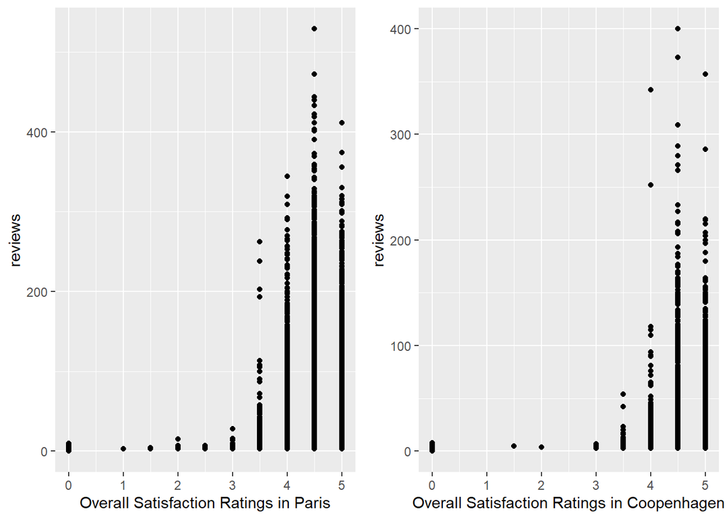

```r
scatter_Paris <- ggplot(paris, aes(x = overall_satisfaction, y = reviews)) +
    geom_point() +
   xlab("Overall Satisfaction Ratings in Paris")

scatter_Chagen <- ggplot(copenhagen, aes(x = overall_satisfaction, y = reviews)) +
    geom_point() +
  xlab("Overall Satisfaction Ratings in Coopenhagen")

grid.arrange(scatter_Paris, scatter_Chagen, ncol=2)
```

```r
summary(paris$overall_satisfaction)
```

```
##    Min. 1st Qu.  Median    Mean 3rd Qu.    Max.
##   0.000   0.000   4.500   2.615   4.500   5.000
```

```r
summary(copenhagen$overall_satisfaction)
```

```
##    Min. 1st Qu.  Median    Mean 3rd Qu.    Max.
##   0.000   0.000   4.500   2.868   5.000   5.000
```

#These are discrete data that take on values of 0,0.5,1.0,1.5,2.0,2.5,3.0,3.5,4.0,4.5,5.0 ONLY.

#If we want to compare these data between paris and Copenhagen.

```r
wilcox.test(paris$overall_satisfaction, copenhagen$overall_satisfaction, paired=FALSE)
```

```
##
##  Wilcoxon rank sum test with continuity correction
##
## data:  paris$overall_satisfaction and copenhagen$overall_satisfaction
## W = 674154758, p-value < 2.2e-16
## alternative hypothesis: true location shift is not equal to 0
```

#Here we see that in fact there is a differnece in satisfaction, even though the data are similar- note the slightly higher ratings in Copenhagen from the summary data.

```r
wilcox.test(paris$overall_satisfaction, copenhagen$overall_satisfaction, paired=FALSE)
```

```
##
##  Wilcoxon rank sum test with continuity correction
##
## data:  paris$overall_satisfaction and copenhagen$overall_satisfaction
## W = 674154758, p-value < 2.2e-16
## alternative hypothesis: true location shift is not equal to 0
```

#NOTE this code is easily converted for use in a paired sample comparison setting (e.g. comparing Likert Questionnaire ratings before-and-after an intervention) where ‘paired=TRUE’ is used.

## Exercise 2.

#(a) Test the following 2 hypotheses:

#(1) The proportion of reviews received by paris properties is the same as that rec’d by c’hagen properties.

#(2) The proportion of reviews received by dublin properties is the same as that rec’d by london properties.

#(b)If you had used a t-test rather than the 2-sample Wilcoxan test for these comparisons, would it have made a difference to the final result. Hint: perform the comparisons again using a t-test. A short one sentence answer is sufficient.

```r
# check for equality of variances of the two price variables
rest.ftestt <- var.test(copenhagen$overall_satisfaction, london$overall_satisfaction)
rest.ftestt
```

```
##
##  F test to compare two variances
##
## data:  copenhagen$overall_satisfaction and london$overall_satisfaction
## F = 0.99615, num df = 21300, denom df = 64143, p-value = 0.7314
## alternative hypothesis: true ratio of variances is not equal to 1
## 95 percent confidence interval:
##  0.9746075 1.0182852
## sample estimates:
## ratio of variances
##          0.9961462
```

```r
# first wilcox test
wilcox.test(copenhagen$overall_satisfaction, london$overall_satisfaction, paired=FALSE)
```

```
##
##  Wilcoxon rank sum test with continuity correction
##
## data:  copenhagen$overall_satisfaction and london$overall_satisfaction
## W = 777200589, p-value < 2.2e-16
## alternative hypothesis: true location shift is not equal to 0
```

```r
# second wilcox test
wilcox.test(copenhagen$overall_satisfaction, london$overall_satisfaction, paired=FALSE)
```

```
##
##  Wilcoxon rank sum test with continuity correction
##
## data:  copenhagen$overall_satisfaction and london$overall_satisfaction
## W = 777200589, p-value < 2.2e-16
## alternative hypothesis: true location shift is not equal to 0
```

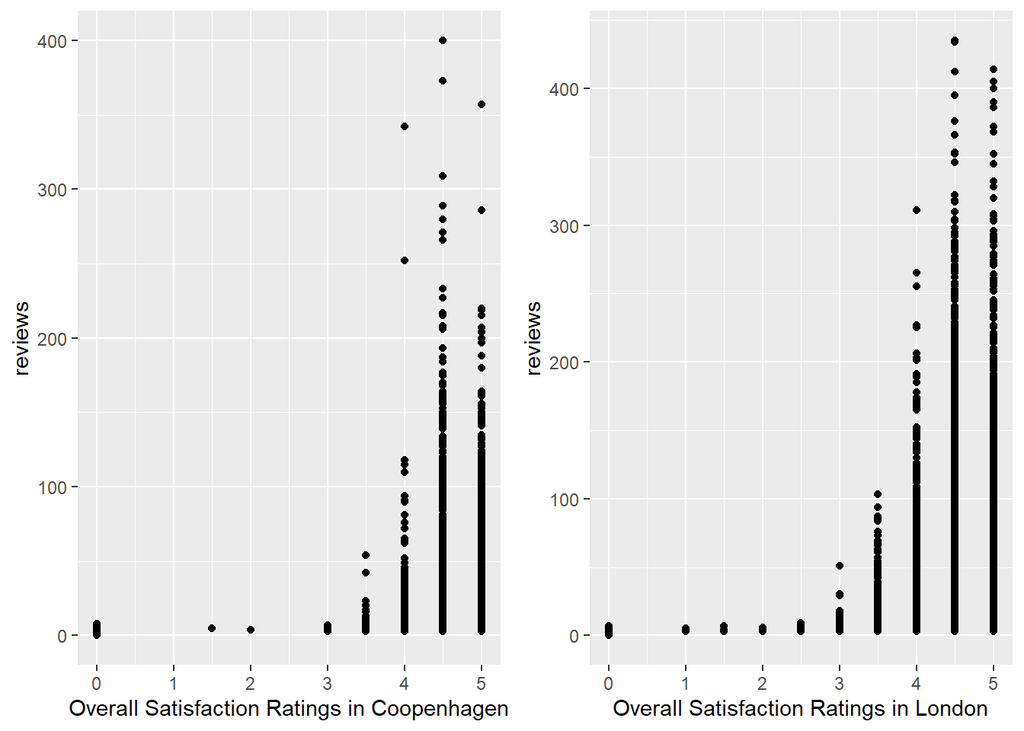

```r
# ggplot code for scatter plots of overall satisfaction vs number of reviews for copenhagen
scatter_Chagen <- ggplot(copenhagen, aes(x = overall_satisfaction, y = reviews)) +
    geom_point() +
  xlab("Overall Satisfaction Ratings in Coopenhagen")

# ggplot code for scatter plots of overall satisfaction vs number of reviews for london
scatter_London <- ggplot(london, aes(x = overall_satisfaction, y = reviews)) +
    geom_point() +
   xlab("Overall Satisfaction Ratings in London")

grid.arrange(scatter_Chagen, scatter_London, ncol=2)
```

```r
# summary for copenhagen and london satisfaction
summary(copenhagen$overall_satisfaction)
```

```
##    Min. 1st Qu.  Median    Mean 3rd Qu.    Max.
##   0.000   0.000   4.500   2.868   5.000   5.000
```

```r
summary(london$overall_satisfaction)
```

```
##    Min. 1st Qu.  Median    Mean 3rd Qu.    Max.
##    0.00    0.00    3.00    2.34    4.50    5.00
```

```r
# ttest for false
ttest_falsev_two <- t.test(copenhagen$overall_satisfaction, london$overall_satisfaction, var.equal = FALSE)
ttest_falsev_two
```

```
##
##  Welch Two Sample t-test
##
## data:  copenhagen$overall_satisfaction and london$overall_satisfaction
## t = 28.495, df = 36521, p-value < 2.2e-16
## alternative hypothesis: true difference in means is not equal to 0
## 95 percent confidence interval:
##  0.4920608 0.5647541
## sample estimates:
## mean of x mean of y
##  2.867917  2.339510
```

```r
# ttest for true
ttest_truev_two <- t.test(copenhagen$overall_satisfaction, london$overall_satisfaction, var.equal = TRUE)
ttest_truev_two
```

```
##
##  Two Sample t-test
##
## data:  copenhagen$overall_satisfaction and london$overall_satisfaction
## t = 28.467, df = 85443, p-value < 2.2e-16
## alternative hypothesis: true difference in means is not equal to 0
## 95 percent confidence interval:
##  0.4920263 0.5647886
## sample estimates:
## mean of x mean of y
##  2.867917  2.339510
```

## Comparing 3 or more groups.

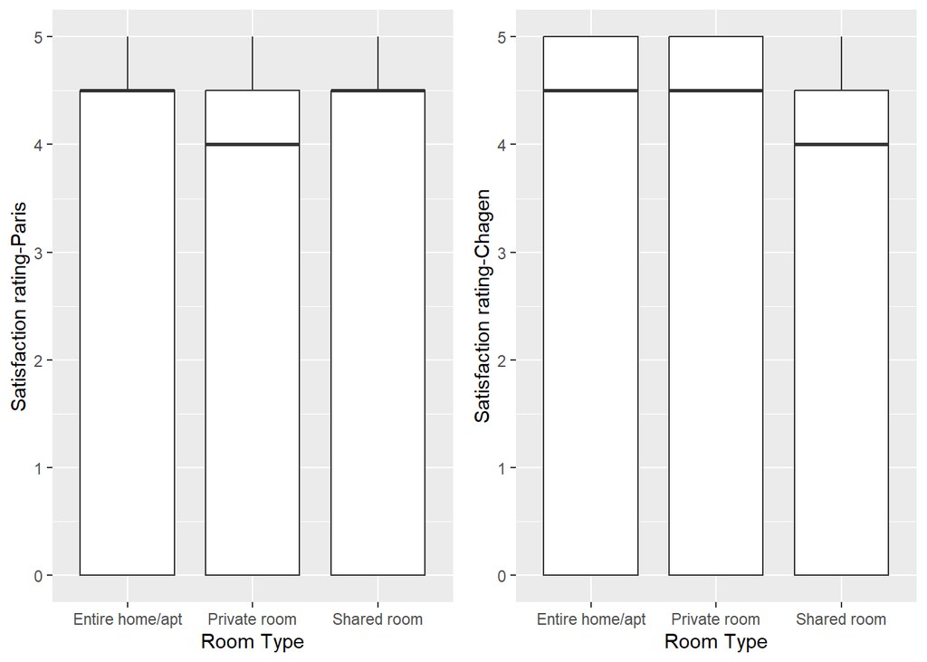

```r
#box plots
parissatbox <- ggplot(paris, aes(x=room_type, y=overall_satisfaction)) +
  geom_boxplot(outlier.colour="red", outlier.shape=1,
                outlier.size=2) +
ylab("Satisfaction rating-Paris")+
  xlab("Room Type")

copenhagensatbox <- ggplot(copenhagen, aes(x=room_type, y=overall_satisfaction)) +
  geom_boxplot(outlier.colour="blue", outlier.shape=1,
                outlier.size=2) +
ylab("Satisfaction rating-Chagen")+
  xlab("Room Type")

grid.arrange(parissatbox , copenhagensatbox , ncol=2)
```

#Here we are interested in whether there is a difference in the overall satisfaction rating according to room type.

#we have 3 types of rooms, so we are no longer comparing just 2 groups. Hence we have to use a different statistic (cannot use Mann-Whitney nor t-tests as these are for 2 group comparisons only).

#To perform a 3 group coamprison on these discrete data, we use a Kruskal-Wallis test, which is the non-parametric equivalent of an ANOVA test.

```r
kruskal.test(overall_satisfaction ~ room_type, data = paris)
```

```
##
##  Kruskal-Wallis rank sum test
##
## data:  overall_satisfaction by room_type
## Kruskal-Wallis chi-squared = 14.766, df = 2, p-value = 0.0006216
```

```r
kruskal.test(overall_satisfaction ~ room_type, data = copenhagen)
```

```
##
##  Kruskal-Wallis rank sum test
##
## data:  overall_satisfaction by room_type
## Kruskal-Wallis chi-squared = 13.426, df = 2, p-value = 0.001215
```

#The Results here tell us that we should reject the null, i.e. there is a difference in satisfaction according to Room Type.

#However we don’t know which pairs are different, we know only that there is a difference among the 3 rooms.

#We need to do whats called a post hoc test to see where the difference or differneces actually are (i.e. which groups differ?).

```r
pairwise.wilcox.test(paris$overall_satisfaction, paris$room_type,
                 p.adjust.method = "bonferroni")
```

```
##
##  Pairwise comparisons using Wilcoxon rank sum test with continuity correction
##
## data:  paris$overall_satisfaction and paris$room_type
##
##              Entire home/apt Private room
## Private room 0.00037         -
## Shared room  1.00000         1.00000
##
## P value adjustment method: bonferroni
```

```r
pairwise.wilcox.test(copenhagen$overall_satisfaction, copenhagen$room_type,
                 p.adjust.method = "bonferroni")
```

```
##
##  Pairwise comparisons using Wilcoxon rank sum test with continuity correction
##
## data:  copenhagen$overall_satisfaction and copenhagen$room_type
##
##              Entire home/apt Private room
## Private room 0.022           -
## Shared room  0.030           0.108
##
## P value adjustment method: bonferroni
```

#Here the results give us p-values for each paired comparison with an adjustment for multiple comparisons (Bonferroni was used in this case,there are others, e.g. try p.adjust.method =‘BH’ which performs the less conservative the Benjamini-Hochberg correction).

#Note that the results differ between paris and c’hagen.

#Note also that the results differ according to the p-value adjustment method, bonferroni is the most strict and is recommended when you have a small number of groups- the BH method may be better and is generally recommended when you are dealing with very large numbers of groups, i.e. 1000s in a big data analysis (also called large p).

#if we had continuous data, we could run a one way ANOVA (Analysis of Variance Analysis).

#we will look at this with the price data.

#here our hypothesis is that there is no differnece in price according to type of room in Paris.

```r
anova1 <- aov(logprice ~ room_type, data = paris)

# Summary of the analysis and post hoc test with Tukey's HSD
summary(anova1)
```

```
##                Df Sum Sq Mean Sq F value Pr(>F)
## room_type       2   2178  1089.2    3580 <2e-16 ***
## Residuals   70155  21346     0.3
## ---
## Signif. codes:  0 '***' 0.001 '**' 0.01 '*' 0.05 '.' 0.1 ' ' 1
```

```r
TukeyHSD(anova1)
```

```
##   Tukey multiple comparisons of means
##     95% family-wise confidence level
##
## Fit: aov(formula = logprice ~ room_type, data = paris)
##
## $room_type
##                                    diff        lwr        upr p adj
## Private room-Entire home/apt -0.5137683 -0.5292331 -0.4983035     0
## Shared room-Entire home/apt  -0.8660663 -0.9232711 -0.8088616     0
## Shared room-Private room     -0.3522980 -0.4110979 -0.2934982     0
```

#The output here gives us a lot of information., on the first row, for room type we see a df of 2 (that means 3(groups)-1) and we see that we get an F-value and an assessment of how probable this F value is under the null, which gives us a p-value of 2x10-16).

#this tells us clearly that we should reject the null, that there is a differnece in price by room type, but which rooms differ?

#the post hoc test, this time using another method (Tukey’s HSD) tells us that all 3 pairs are different in price (p values lower than 0.0001)

#Note there are several assumptions which must be valid before doing an AVOVA.

#1.The observations were obtained independently and randomly from the population defined by the factor levels or groups.

#2.The data of each factor level (each group) are normally distributed.

#3.These normal populations have equal variances (use Levene’s test for homogeneity of variance).

#assumption 1 is tested the residual(errors) qq plots, assumption 2 using qq plots, and assumption 3 using a test called Levene’s test.

#………………………………………………………………………………………………………………….